# Module 3: Excel & Data Analytics (7.5 Hours)

From Raw Data to Business Insights

Author

Dr Aniruddha Bonnerjee

Abstract

Session 3: Mastering Pivot Tables

# Session 3: Mastering Pivot Tables

### Duration: 2 hours

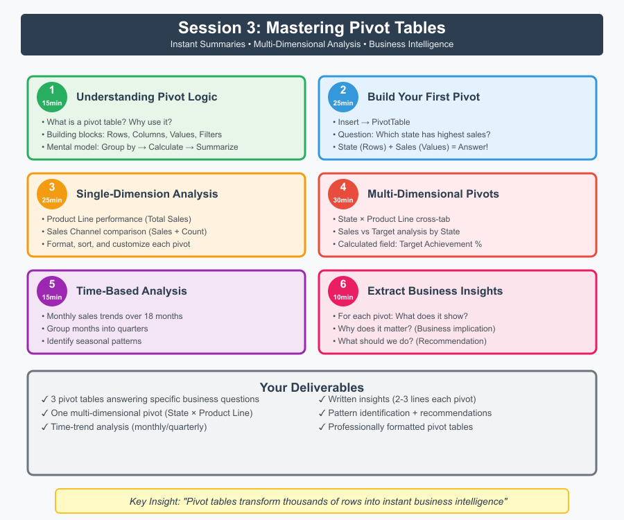

## Session Objective

By the end of this session, you will be able to: - Understand the logic and power of pivot tables - Build pivot tables to summarize thousands of rows instantly - Create single-dimension analysis (one category at a time) - Build multi-dimensional pivots (cross-tabulations) - Use calculated fields within pivots - Group data by time periods or value ranges - Extract meaningful business insights from pivot analysis - Format and customize pivots for professional presentation

## Why Pivot Tables Matter

Imagine you have 1000 rows of sales data. Your boss asks:

*“Which state is performing best? How do our sales channels compare? Are we meeting targets? Which products are most profitable?”*

You could spend hours manually calculating totals, using formulas, copying data around…

**Or you could create pivot tables in 2 minutes each.**

**Important**

Pivot tables are the single most powerful analysis tool in Excel. They turn raw data into instant business intelligence.

**Today’s mindset shift:** You’re not learning a technical feature. You’re learning how to think like an analyst—how to ask questions and let the data answer them systematically.

## Today’s Dataset

We’re continuing with your **cleaned and enriched Company Sales Performance Data** from Sessions 1 & 2.

**What you now have:** - 1000 clean transaction records (duplicates removed) - 8 states, multiple branches, 5 product lines - 18 months of data (Jan 2023 - Jun 2024) - Sales, Sales Targets, Channels, Customer Segments - **NEW: Product Category** (from lookups) - **NEW: Profit Margin %** (from lookups) - **NEW: Total Profit** (calculated) - **NEW: Performance flags** (from IF functions)

**This enriched dataset is PERFECT for pivot analysis!**

## Part 1: Understanding Pivot Logic (15 minutes)

### What IS a Pivot Table?

A pivot table takes detailed transactional data and **summarizes it by categories you choose**.

Think of it as asking Excel: > “Group my data by [State], and tell me the total [Sales] for each one.”

**The Magic Formula:**

```
Detailed Data → Group By Category → Calculate Totals/Averages/Counts → Summary View
```

### The Restaurant Menu Analogy

**Without Pivot Table (Raw Orders):**

```
Order 1: Pasta, ₹500
Order 2: Pizza, ₹800
Order 3: Pasta, ₹450
Order 4: Burger, ₹350
Order 5: Pizza, ₹900
... (500 more orders)
```

**With Pivot Table (Grouped by Dish):**

```
Pasta:   ₹1,200 total (3 orders)
Pizza:   ₹2,100 total (5 orders)
Burger:  ₹850 total (2 orders)
```

You went from 500 rows to 3 summary rows. **That’s the power of pivoting.**

### The Four Building Blocks

Every pivot table has **four** components:

#### 1. Rows - What you want to group by vertically

**Example:** States (Maharashtra, Karnataka, Tamil Nadu…)

This creates one row per unique value.

#### 2. Columns - What you want to group by horizontally (optional)

**Example:** Months (Jan-2023, Feb-2023, Mar-2023…)

This creates one column per unique value. Creates a cross-tabulation.

#### 3. Values - What you want to calculate

**Example:** Sum of Sales, Count of Transactions, Average Sales

This is the actual numbers that appear in your pivot table.

#### 4. Filters - What you want to include/exclude (optional)

**Example:** Show only “Online” channel, or only “B2B” customers

This lets you focus on specific subsets without rebuilding the pivot.

### Mental Model: The Pivot Machine

Think of a pivot table as a machine:

```
INPUT (Raw Data)
    ↓
[GROUP BY: State]
    ↓
[CALCULATE: Sum of Sales]
    ↓
OUTPUT (Summary Table)
Maharashtra: ₹12.5M
Karnataka: ₹8.2M
Tamil Nadu: ₹6.8M
...
```

The beauty? You can instantly change the grouping or calculation!

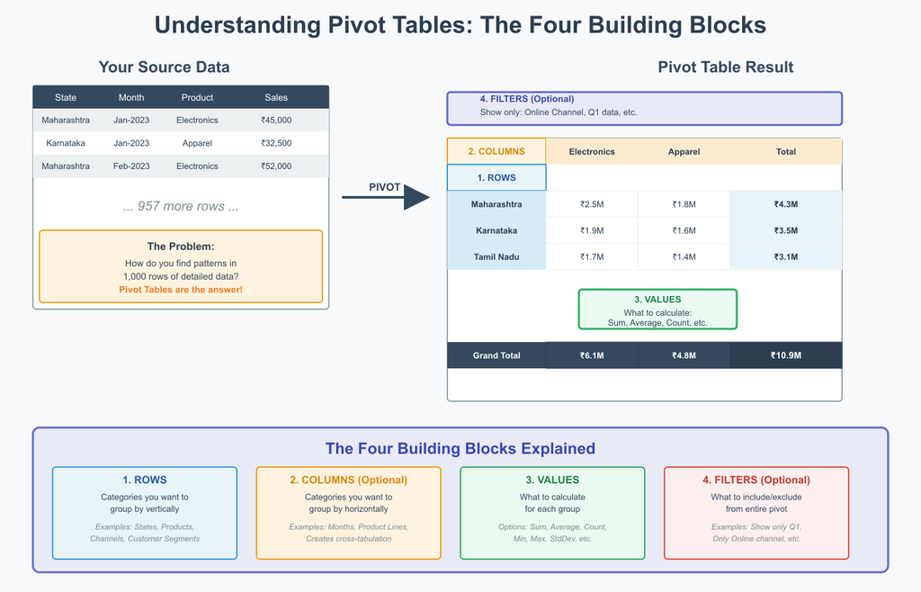

### Why “Pivot”?

The term comes from the ability to quickly **“pivot”** (rotate) your view of the data.

You can instantly switch from: - Sales by State → Sales by Product Line - Monthly totals → Quarterly totals - Channel comparison → Customer segment comparison

**All without changing your source data. One dataset, infinite perspectives.**

## Part 2: Build Your First Pivot (25 minutes)

### Step-by-Step: Your First Pivot Table

**Business Question:** Which state has the highest total sales?

#### Step 1: Select Your Data

1. Click **anywhere** in your dataset
2. Excel will automatically detect the data range
3. Make sure your data has clear column headers (it should from Session 1 and 2!)

**Tip**

**Pro tip:** You don’t need to select the entire range—Excel finds it automatically if your data is continuous.

#### Step 2: Insert Pivot Table

1. Go to **Insert** tab in ribbon
2. Click **PivotTable** button
3. Excel will ask: “Where do you want the PivotTable?”
4. Choose **New Worksheet** (keeps your analysis separate from raw data)
5. Click **OK**

**What you’ll see:** - A blank area on the left (where your pivot will appear) - **PivotTable Fields** panel on the right (your control center!)

#### Step 3: Build Your Pivot

In the PivotTable Fields panel, you’ll see: - A list of all your column names at the top - Four boxes at the bottom: Filters, Columns, Rows, Values

**To answer “Which state has highest sales?”:**

1. **Drag “State”** from the field list → into **Rows** box
2. **Drag “Sales”** from the field list → into **Values** box

**Boom!** You now have total sales by state.

Excel automatically: - Creates one row per state - Sums all sales for each state - Displays the results

#### Step 4: Format for Clarity

Make your pivot table professional:

**Rename the measure:** 1. Click on “Sum of Sales” in the pivot table 2. Right-click → **Value Field Settings** 3. Change “Custom Name” to “Total Sales” 4. Click **OK**

**Format as currency:** 1. Right-click on any number in the Total Sales column 2. **Number Format** → **Currency** → Select ₹ symbol 3. Click **OK**

**Sort by Total Sales (highest to lowest):** 1. Click dropdown arrow next to “Row Labels” 2. **Sort** → **More Sort Options** 3. Choose “Descending (Z to A)” by “Total Sales” 4. Click **OK**

**Your first pivot is complete!**

### Practice Exercise 1: Product Line Performance

Before moving on, create a second pivot table:

**Question:** Which product line generates the most revenue?

1. Insert a new pivot table (same data)
2. **Rows:** Product_Line
3. **Values:** Sales (Sum)
4. Format as currency
5. Sort by Total Sales descending

**Bonus:** Also add Count of Transaction_ID to see how many transactions per product line.

**To add a second measure:** - Drag “Transaction_ID” to the Values box - It will show “Count of Transaction_ID” - Now you can see both Total Sales AND Transaction Count!

## Part 3: Single-Dimension Analysis (25 minutes)

### Multiple Measures in One Pivot

Let’s build a comprehensive state analysis with multiple metrics.

**Create a new pivot table:**

**Rows:** State

**Values:** (drag these one by one) 1. Sales → will show “Sum of Sales” 2. Transaction_ID → will show “Count of Transaction_ID” 3. Sales (again!) → will show “Sum of Sales2”

**Wait, we added Sales twice?** Yes! Here’s why:

**Configure the second Sales field:** 1. Click on “Sum of Sales2” in the pivot 2. Value Field Settings 3. Change calculation to **Average** 4. Rename to “Average Sale” 5. Click OK

**Now you have:** - Total Sales (sum) - Transaction Count - Average Sale per Transaction

**This is POWERFUL!** One pivot, three business metrics.

### Adding Calculated Metrics

**Let’s add “Average Transaction Value” manually:**

Actually, we already did this above! The Average of Sales gives us average transaction value.

**But let’s also calculate “Sales per Transaction” differently:**

In your summary, you can add a column outside the pivot:

```
= Total Sales / Transaction Count
```

### Channel Performance Analysis

**Create a new pivot:**

**Rows:** Sales_Channel

**Values:** 1. Sales (Sum) → Total Sales 2. Transaction_ID (Count) → Transaction Count 3. Sales (Average) → Average Sale 4. Total_Profit (Sum) → Total Profit

**Format everything appropriately:** - Currency for Sales and Profit - Number format for Count - Currency for Average

**Business Questions to answer:** 1. Which channel drives most revenue? 2. Which channel has highest average transaction? 3. Which channel is most profitable? 4. How do transaction counts compare?

### Customer Segment Analysis

**Create a new pivot:**

**Rows:** Customer_Segment

**Values:** 1. Sales (Sum) 2. Transaction_ID (Count) 3. Total_Profit (Sum)

**Add a calculated field for Profit Margin:** 1. Click anywhere in the pivot 2. **PivotTable Analyze** tab → **Fields, Items & Sets** → **Calculated Field** 3. Name: “Profit Margin %” 4. Formula: `= Total_Profit / Sales * 100` 5. Click **Add** → **OK**

**Note**

**Note:** Calculated Fields are powerful but have limitations. Sometimes it’s easier to calculate in the source data first (which we did!).

### Practice Exercise 2: Build Three Pivots

Create these on your own:

1. **Performance by Month**
   - Rows: Month
   - Values: Sales (Sum), Target Achievement Count
2. **Product Category Analysis**
   - Rows: Product_Category (from your lookups!)
   - Values: Sales, Profit, Count
3. **Branch Performance**
   - Rows: Branch_Location
   - Values: Sales, Count, Average Sale

## Part 4: Multi-Dimensional Pivots (30 minutes)

### Understanding Cross-Tabulation

Sometimes you want to see TWO dimensions at once: - Sales by State AND Product Line - Sales by Month AND Channel - Performance by State AND Customer Segment

This is called **cross-tabulation** or a **two-way table**.

### Example 1: State × Product Line

**Business Question:** Which products perform best in which states?

**Create a new pivot:**

**Rows:** State

**Columns:** Product_Line

**Values:** Sales (Sum)

**What you get:** A grid showing sales for every State-Product combination!

**Example result:**

```
                Electronics  Apparel  Home & Kitchen  Beauty  Sports
Maharashtra     ₹2.5M       ₹1.8M    ₹2.1M          ₹1.2M   ₹1.5M
Karnataka       ₹1.8M       ₹2.2M    ₹1.5M          ₹1.8M   ₹1.2M
Tamil Nadu      ₹1.5M       ₹1.2M    ₹1.8M          ₹1.5M   ₹1.8M
...
```

**Insights to look for:** - Are certain products strong in specific regions? - Do all states have similar product mix? - Where are the gaps (low sales combinations)? - Should marketing focus differ by region?

### Example 2: Sales vs Target by State

**Business Question:** Which states are meeting targets? By how much?

**Create a new pivot:**

**Rows:** State

**Values:** 1. Sales (Sum) → Total Sales 2. Sales_Target (Sum) → Total Target

**Add a Calculated Field:** 1. PivotTable Analyze → Fields, Items & Sets → Calculated Field 2. Name: “Achievement %” 3. Formula: `= Sales / Sales_Target * 100` 4. Click Add → OK

**Sort by Achievement % to see:** - Who’s exceeding targets (>100%) - Who’s falling short (<100%) - By how much

**Format the Achievement % as percentage:** - Right-click → Value Field Settings → Number Format → Percentage → 1 decimal place

### Example 3: Channel × Customer Segment

**Business Question:** Which combinations drive the most value?

**Rows:** Sales_Channel

**Columns:** Customer_Segment

**Values:** 1. Sales (Sum) 2. Total_Profit (Sum)

**What this reveals:** - Is B2B mainly through Distributors? - Does Online work better for B2C? - Which combination is most profitable?

### Example 4: Month × Product Category (Trend Analysis)

**Rows:** Month

**Columns:** Product_Category

**Values:** Sales (Sum)

**To sort months chronologically:** 1. Right-click on any month 2. Sort → More Sort Options 3. Manual sort (drag and drop in correct order) OR better: 4. Use a helper column in your source data with Month Number (1-18)

**Insights to look for:** - Seasonal patterns - Growing or declining categories - Monthly volatility

### Grouping Data in Pivots

**Grouping Months into Quarters:**

1. Right-click on any month in your pivot
2. **Group**
3. If Excel recognizes dates, choose “Quarters”
4. Click OK

**If your Month field is text** (like “Jan-2023”): - You might need to manually create a Quarter field in your source data - Or use helper columns

**Grouping Sales into Ranges:**

If you have Sales in Rows: 1. Right-click on any sales value 2. **Group** 3. Starting at: 0 4. Ending at: 100000 5. By: 20000 6. Click OK

This creates buckets: 0-20K, 20K-40K, 40K-60K, etc.

### Practice Exercise 3: Multi-Dimensional Analysis

Create these pivots:

1. **State × Sales_Channel**
   - Which channels work best in which states?
2. **Product_Line × Performance** (Target Met/Missed)
   - Which products consistently meet targets?
3. **Month × Channel**
   - How do channels perform over time?

## Part 5: Time-Based Analysis (15 minutes)

### Monthly Trends

**Business Question:** How are sales trending over our 18-month period?

**Create a new pivot:**

**Rows:** Month (in chronological order)

**Values:** Sales (Sum)

**Make it visual:** 1. Click anywhere in the pivot 2. **PivotTable Analyze** tab → **PivotChart** 3. Choose **Line Chart** 4. Format chart with clear title and axis labels

**What to look for:** - Overall growth or decline? - Seasonal patterns? - Any anomalies (sudden spikes or drops)?

### Quarterly Summaries

If you can group months into quarters:

**Rows:** Quarter

**Values:** 1. Sales (Sum) 2. Sales_Target (Sum) 3. Achievement %

**Compare:** - Q1 2023 vs Q1 2024 (year-over-year) - Quarter-to-quarter growth

### Year-over-Year Comparison

**If you have data across full years:**

**Rows:** Month_Name (e.g., “January”, “February”…)

**Columns:** Year (2023, 2024)

**Values:** Sales (Sum)

**This shows:** How each month performed year-over-year.

### Practice Exercise 4: Time Analysis

1. **Create monthly trend pivot** with Sales and Profit
2. **Add a PivotChart** to visualize the trend
3. **Identify:**
   - Best performing month
   - Worst performing month
   - Any seasonal patterns

## Part 6: Extract Business Insights (10 minutes)

### From Numbers to Narrative

A pivot table without interpretation is just formatted data. Your job is to extract **insights**—patterns that lead to action.

**The “So What?” Test**

For every pivot table you create, ask: 1. **What does this tell me?** (The pattern) 2. **Why does it matter?** (The implication) 3. **What should we do?** (The recommendation)

### Example: Strong Analysis

**Pivot Result:**

```
Maharashtra: ₹12.5M sales (Target: ₹10M) → 125% achievement
Uttar Pradesh: ₹8.2M sales (Target: ₹9M) → 91% achievement
```

**Weak Response:** > “Maharashtra has higher sales than UP.”

**Strong Response:** > “Maharashtra is exceeding targets by 25% while UP is falling short by 9%. This suggests either: (1) UP targets were set too aggressively, (2) Maharashtra has operational advantages worth replicating, or (3) UP faces market challenges requiring investigation. **Recommendation:** Interview top performers in Maharashtra to identify best practices, and conduct market analysis in UP to understand barriers.”

**See the difference?** One just repeats the numbers. The other thinks like a business analyst.

### The Insight Formula

```
DATA PATTERN + BUSINESS CONTEXT + ACTION = INSIGHT
```

**Example patterns to look for:**

**In State Analysis:** - One state dramatically outperforming → Why? Can we replicate? - One state underperforming → What’s the barrier?

**In Product Analysis:** - High sales but low profit margin → Pricing issue? - Low sales but high profit margin → Marketing opportunity?

**In Channel Analysis:** - One channel has high average transaction → Focus resources here? - Another has high volume, low value → Optimize for scale?

**In Time Analysis:** - Declining trend → Urgent action needed - Seasonal spike → Plan inventory accordingly - Consistent growth → What’s working? Do more of it!

### Practice: Write Your Insights

For each pivot you created today, write a 2-3 line insight:

**Template:**

```
Finding: [State the key pattern from your pivot table]

Implication: [Explain why this matters for the business]

Recommendation: [Suggest one concrete action based on this insight]
```

## Your Deliverables Checklist

By the end of this session, you should have:

### ✓ Three Single-Dimension Pivot Tables

At least three of: 1. State performance (Sales, Count, Average) 2. Product Line analysis 3. Channel comparison 4. Customer Segment breakdown 5. Monthly trends

**Each should answer a specific business question!**

### ✓ One Multi-Dimensional Pivot Table

Choose one of: 1. State × Product Line (regional product performance) 2. Channel × Customer Segment (channel-segment combinations) 3. Month × Product Category (trends by category) 4. State × Target Achievement (performance tracking)

**This should reveal cross-category patterns.**

### ✓ Time-Based Analysis

Either: - Monthly trend (18 months) - Quarterly summary (if you can group) - Year-over-year comparison (if applicable)

### ✓ Written Insights (2-3 lines per pivot)

For at least 3 pivots, write: - Finding (what the data shows) - Implication (why it matters) - Recommendation (what to do)

**Example format:**

```
Pivot: State Performance

Finding: Maharashtra leads with ₹12.5M in sales (32% of total),
exceeding its target by 25%. UP is the only state below target.

Implication: Maharashtra's practices are working and should be studied.
UP needs immediate attention as it's at risk of missing annual goals.

Recommendation:
1. Interview Maharashtra's top 3 branches to identify success factors
2. Assign senior manager to diagnose UP challenges within 2 weeks
3. Reallocate 10% of marketing budget from saturated states to UP
```

### Pivot Table Best Practices

**1. Always name your pivot tables:** - Click on pivot → PivotTable Analyze → PivotTable Name - Use descriptive names: “State_Sales_Summary”, not “PivotTable1”

**2. Keep source data clean:** - Pivots reflect your source data - Garbage in = Garbage out

**3. Refresh after source data changes:** - Right-click pivot → **Refresh** - Or: PivotTable Analyze → Refresh

**4. Use Slicers for interactive filtering:** - PivotTable Analyze → Insert Slicer - Choose fields (e.g., State, Channel) - Creates visual filter buttons - Great for presentations!

**5. Copy pivot values for reports:** - Select pivot → Copy - Paste Special → **Values** - Converts live pivot to static numbers

### Formatting Tips

**1. Number Formatting:** - Always format currency as ₹ - Use thousand separators (commas) - Percentages with 1-2 decimal places

**2. Conditional Formatting in Pivots:** - Home → Conditional Formatting → Color Scales - Highlight high/low values automatically - Great for spotting patterns quickly

**3. Remove Clutter:** - Design tab → Report Layout → Show in Tabular Form - Removes extra indentation and subtotals

**4. Grand Totals:** - Design tab → Grand Totals - Choose: On for Rows and Columns, or Off

## Common Pivot Table Mistakes to Avoid

❌ **Building pivots on uncleaned data** - Always clean first (Session 1!), then pivot

❌ **Not refreshing after source data changes** - Pivot shows OLD data until you refresh - Keyboard shortcut: Alt + F5

❌ **Too many dimensions in one pivot** - Rows + Columns + Multiple Values = Confusing - Keep pivots focused on one question

❌ **Forgetting to format** - Raw numbers without ₹ or % look unprofessional - Take 30 seconds to format properly

❌ **No insight narrative** - A pivot without interpretation is just a table - Always ask “So what?” and write it down

❌ **Overcomplicating the first pivot** - Start simple: 1 Row, 1 Value - Add complexity gradually

## Key Takeaways

✓ **Pivot tables = Business intelligence in seconds** - Master this, and you’re 10x more valuable

✓ **Think in questions, not features** - Start with “What do I want to know?” not “Which buttons do I click?”

✓ **One dataset, infinite views** - The power is in how quickly you can pivot perspectives

✓ **Numbers without context are meaningless** - Always interpret, always connect to decisions

✓ **Multi-dimensional analysis reveals hidden patterns** - State performance alone is one story; State × Product reveals much more

✓ **Practice builds intuition** - The more pivots you build, the faster you’ll “see” the answer in the data

## What’s Next?

**Session 4: Visualization & Capstone Project**

Now that you can analyze data with pivot tables, you’ll learn to: - Choose the right chart type for your message - Create clear, professional visualizations - Build insight narratives that drive action - Present findings to non-technical audiences - **Complete a group capstone project:** Receive new FMCG data, analyze it, and present insights in 25 minutes

**The final skill:** Making data speak to people who don’t live in spreadsheets.

Your journey so far: - ✓ Session 1: Cleaned messy data - ✓ Session 2: Enriched it with formulas and lookups - ✓ Session 3: Summarized it with pivot tables - → Session 4: Visualize it and present it convincingly

You’re building the complete analyst skillset!

## Bonus Challenge (Optional)

If you finish early or want extra practice:

**The Executive Dashboard Challenge**

Create a single-sheet dashboard with 4 pivot tables that answers: 1. Which state should we prioritize for investment? 2. Which product-channel combinations are underperforming? 3. Are we improving over time or declining? 4. What’s our biggest opportunity for growth?

**Requirements:** - 4 pivot tables on one sheet - Formatted professionally - One-paragraph insight per pivot - Should fit on one printed page

Think like you’re presenting to the CEO!

## Questions to Reflect On

Before next session, think about:

1. What business questions from your organization could you answer with pivot tables?
2. How much time could pivots save in your monthly reporting?
3. What data would you need to add to your current datasets to make them more powerful?
4. How would you explain pivot tables to a non-technical colleague?

*Module 3: Excel & Data Analytics | Session 3 of 4*